# R5-HypothesisTesting

OGabriel

03/11/2020

## Exercise 1:

For the data InsectSpray, make a table for the number of insects for each spray with the mean, median and standard error.

### Summary of the data InsectSpray for a general overview of the data

```
##      count       spray
##  Min.   : 0.00   A:12
##  1st Qu.: 3.00   B:12
##  Median : 7.00   C:12
##  Mean   : 9.50   D:12
##  3rd Qu.:14.25   E:12
##  Max.   :26.00   F:12
```

Table 1. Insect count as a result of spray

| Spray | Insect_Number | Mean | Standard_error | Median |
| --- | --- | --- | --- | --- |
| A | 174 | 14.50 | 1.36 | 14.0 |
| B | 184 | 15.33 | 1.23 | 16.5 |
| C | 25 | 2.08 | 0.57 | 1.5 |
| D | 59 | 4.92 | 0.72 | 5.0 |
| E | 42 | 3.50 | 0.50 | 3.0 |
| F | 200 | 16.67 | 1.79 | 15.0 |

## Exercise 2:

Print a plot to see the differences of counts between sprays. Include a caption explaining the figure. Which type of plot is the one you choose and why?

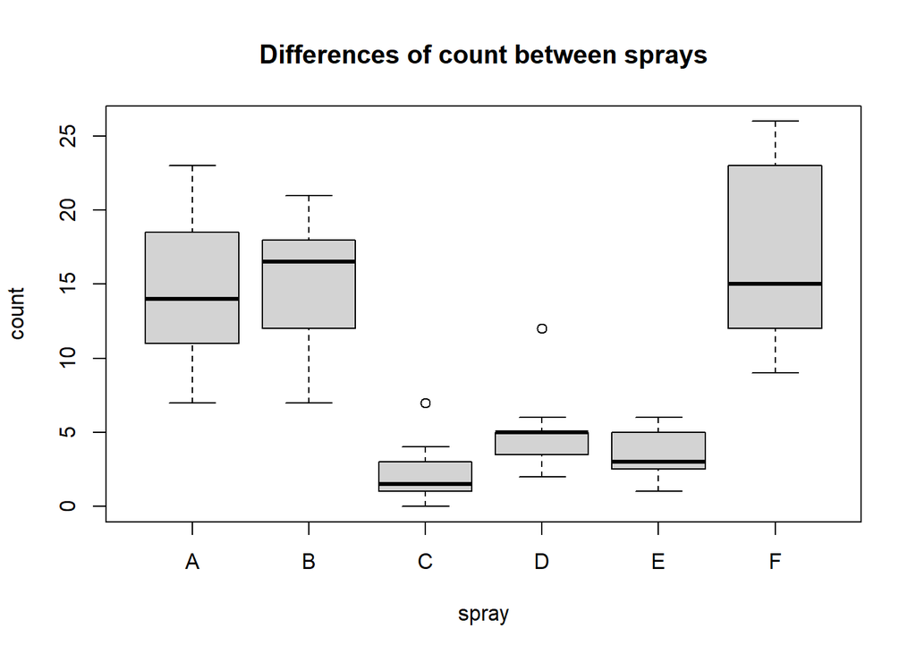

Figure 1. Differences of counts between sprays

## Exercise 3:

Test for differences between sprays using anova and a posthoc comparison and redo the previous plot including the representation of all posthoc differences.

Note: for the anova use the command aov() and for the posthoc comparison use the Tukey’s ‘Honest Significant Difference’ method. For this method try the TukeyHSD() and the agricolae::HSD.test() and see the differences.

### ANOVA: res.aov1

```
##             Df Sum Sq Mean Sq F value Pr(>F)
## spray        5   2669   533.8    34.7 <2e-16 ***
## Residuals   66   1015    15.4
## ---
## Signif. codes:  0 '***' 0.001 '**' 0.01 '*' 0.05 '.' 0.1 ' ' 1
```

### TukeyHSD

```
##   Tukey multiple comparisons of means
##     95% family-wise confidence level
##
## Fit: aov(formula = count ~ spray, data = InsectSprays)
##
## $spray
##            diff        lwr       upr     p adj
## B-A   0.8333333  -3.866075  5.532742 0.9951810
## C-A -12.4166667 -17.116075 -7.717258 0.0000000
## D-A  -9.5833333 -14.282742 -4.883925 0.0000014
## E-A -11.0000000 -15.699409 -6.300591 0.0000000
## F-A   2.1666667  -2.532742  6.866075 0.7542147
## C-B -13.2500000 -17.949409 -8.550591 0.0000000
## D-B -10.4166667 -15.116075 -5.717258 0.0000002
## E-B -11.8333333 -16.532742 -7.133925 0.0000000
## F-B   1.3333333  -3.366075  6.032742 0.9603075
## D-C   2.8333333  -1.866075  7.532742 0.4920707
## E-C   1.4166667  -3.282742  6.116075 0.9488669
## F-C  14.5833333   9.883925 19.282742 0.0000000
## E-D  -1.4166667  -6.116075  3.282742 0.9488669
## F-D  11.7500000   7.050591 16.449409 0.0000000
## F-E  13.1666667   8.467258 17.866075 0.0000000
```

### agricolae::HSD.test

```
##
## Study: res.aov1 ~ "spray"
##
## HSD Test for count
##
## Mean Square Error:  15.38131
##
## spray,  means
##
##       count      std  r Min Max
## A 14.500000 4.719399 12   7  23
## B 15.333333 4.271115 12   7  21
## C  2.083333 1.975225 12   0   7
## D  4.916667 2.503028 12   2  12
## E  3.500000 1.732051 12   1   6
## F 16.666667 6.213378 12   9  26
##
## Alpha: 0.05 ; DF Error: 66
## Critical Value of Studentized Range: 4.150851
##
## Minimun Significant Difference: 4.699409
##
## Treatments with the same letter are not significantly different.
##
##       count groups
## F 16.666667      a
## B 15.333333      a
## A 14.500000      a
## D  4.916667      b
## E  3.500000      b
## C  2.083333      b
```

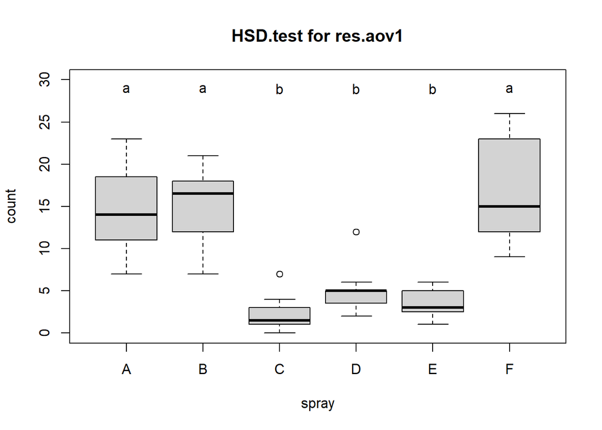

Figure 2. HSD.test for res.aov1

## Exercise 4:

Test for differences between sprays using non-parametric Kruskal-Wallis rank sum test. Again, redo the plot with these results. Use agricolae::kruskal()

### Summary

```
## 'data.frame':    72 obs. of  2 variables:
##  $ count: num  10 7 20 14 14 12 10 23 17 20 ...
##  $ spray: Factor w/ 6 levels "A","B","C","D",..: 1 1 1 1 1 1 1 1 1 1 ...
```

```
## $statistics
##      Chisq Df      p.chisq  t.value      MSD
##   54.69134  5 1.510845e-10 1.996564 8.462804
##
## $parameters
##             test p.ajusted             name.t ntr alpha
##   Kruskal-Wallis      none InsectSprays$spray   6  0.05
##
## $means
##   InsectSprays.count     rank      std  r Min Max   Q25  Q50   Q75
## A          14.500000 52.16667 4.719399 12   7  23 11.50 14.0 17.75
## B          15.333333 54.83333 4.271115 12   7  21 12.50 16.5 17.50
## C           2.083333 11.45833 1.975225 12   0   7  1.00  1.5  3.00
## D           4.916667 25.58333 2.503028 12   2  12  3.75  5.0  5.00
## E           3.500000 19.33333 1.732051 12   1   6  2.75  3.0  5.00
## F          16.666667 55.62500 6.213378 12   9  26 12.50 15.0 22.50
##
## $comparison
## NULL
##
## $groups
##   InsectSprays$count groups
## F           55.62500      a
## B           54.83333      a
## A           52.16667      a
## D           25.58333      b
## E           19.33333     bc
## C           11.45833      c
##
## attr(,"class")
## [1] "group"
```

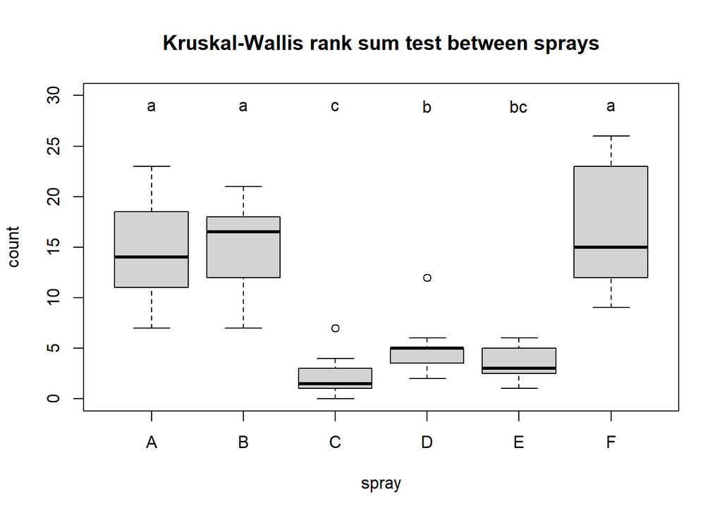

Figure 3. Kruskal-Wallis rank sum test between sprays

## Exercise 5:

Transform count data using sqrt(count) and redo the anova, the Tukey posthoc comparison and the plot.

### Transforming count data of InsectSprays using sqrt(count)

```
##  [1] 3.162278 2.645751 4.472136 3.741657 3.741657 3.464102 3.162278 4.795832
##  [9] 4.123106 4.472136 3.741657 3.605551 3.316625 4.123106 4.582576 3.316625
## [17] 4.000000 3.741657 4.123106 4.123106 4.358899 4.582576 2.645751 3.605551
## [25] 0.000000 1.000000 2.645751 1.414214 1.732051 1.000000 1.414214 1.000000
## [33] 1.732051 0.000000 1.000000 2.000000 1.732051 2.236068 3.464102 2.449490
## [41] 2.000000 1.732051 2.236068 2.236068 2.236068 2.236068 1.414214 2.000000
## [49] 1.732051 2.236068 1.732051 2.236068 1.732051 2.449490 1.000000 1.000000
## [57] 1.732051 1.414214 2.449490 2.000000 3.316625 3.000000 3.872983 4.690416
## [65] 3.872983 4.000000 3.605551 3.162278 5.099020 5.099020 4.898979 3.605551
```

### ANOVA after count transformation using sqrt(count): res.aov2

```
##             Df Sum Sq Mean Sq F value Pr(>F)
## spray        5  88.44  17.688    44.8 <2e-16 ***
## Residuals   66  26.06   0.395
## ---
## Signif. codes:  0 '***' 0.001 '**' 0.01 '*' 0.05 '.' 0.1 ' ' 1
```

### TukeyHSD

```
##   Tukey multiple comparisons of means
##     95% family-wise confidence level
##
## Fit: aov(formula = sqct ~ spray, data = InsectSprays)
##
## $spray
##           diff        lwr        upr     p adj
## B-A  0.1159530 -0.6369601  0.8688661 0.9975245
## C-A -2.5158217 -3.2687349 -1.7629086 0.0000000
## D-A -1.5963245 -2.3492377 -0.8434114 0.0000006
## E-A -1.9512174 -2.7041305 -1.1983042 0.0000000
## F-A  0.2579388 -0.4949744  1.0108519 0.9144964
## C-B -2.6317747 -3.3846879 -1.8788616 0.0000000
## D-B -1.7122775 -2.4651907 -0.9593644 0.0000001
## E-B -2.0671704 -2.8200835 -1.3142572 0.0000000
## F-B  0.1419858 -0.6109274  0.8948989 0.9935788
## D-C  0.9194972  0.1665841  1.6724103 0.0080813
## E-C  0.5646043 -0.1883088  1.3175175 0.2512638
## F-C  2.7737605  2.0208474  3.5266736 0.0000000
## E-D -0.3548928 -1.1078060  0.3980203 0.7366389
## F-D  1.8542633  1.1013502  2.6071764 0.0000000
## F-E  2.2091561  1.4562430  2.9620693 0.0000000
```

### agricolae::HSD

```
##
## Study: res.aov2 ~ "spray"
##
## HSD Test for sqct
##
## Mean Square Error:  0.3948178
##
## spray,  means
##
##       sqct       std  r      Min      Max
## A 3.760678 0.6243234 12 2.645751 4.795832
## B 3.876631 0.5768841 12 2.645751 4.582576
## C 1.244857 0.7630074 12 0.000000 2.645751
## D 2.164354 0.5033405 12 1.414214 3.464102
## E 1.809461 0.4963695 12 1.000000 2.449490
## F 4.018617 0.7512773 12 3.000000 5.099020
##
## Alpha: 0.05 ; DF Error: 66
## Critical Value of Studentized Range: 4.150851
##
## Minimun Significant Difference: 0.7529131
##
## Treatments with the same letter are not significantly different.
##
##       sqct groups
## F 4.018617      a
## B 3.876631      a
## A 3.760678      a
## D 2.164354      b
## E 1.809461     bc
## C 1.244857      c
```

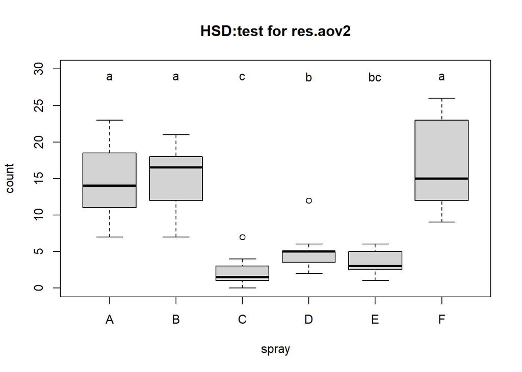

Figure 4.HSD:test for res.aov2

## Exercise 6:

Test for normality of residuals for the two performed anova analyses of points 4 and 6 using shapiro.test() and use plot the anova to see the qqplots and compare them.

### Shapiro.test for the ANOVA res.aov1

```
##
##  Shapiro-Wilk normality test
##
## data:  res.aov1$residuals
## W = 0.96006, p-value = 0.02226
```

### Shapiro.test for the ANOVA res.aov2

```
##
##  Shapiro-Wilk normality test
##
## data:  res.aov2$residuals
## W = 0.98721, p-value = 0.6814
```

### QQplot for comparison

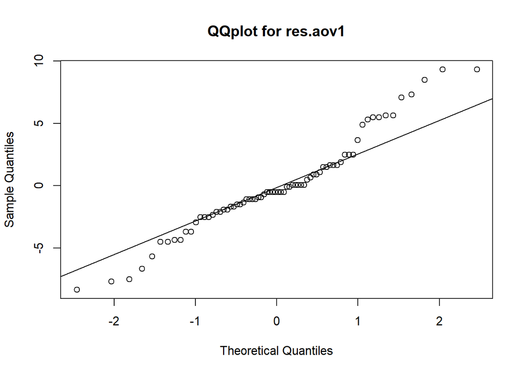

Figure 5. QQplot for comparison for res.aov1 and res.aov2

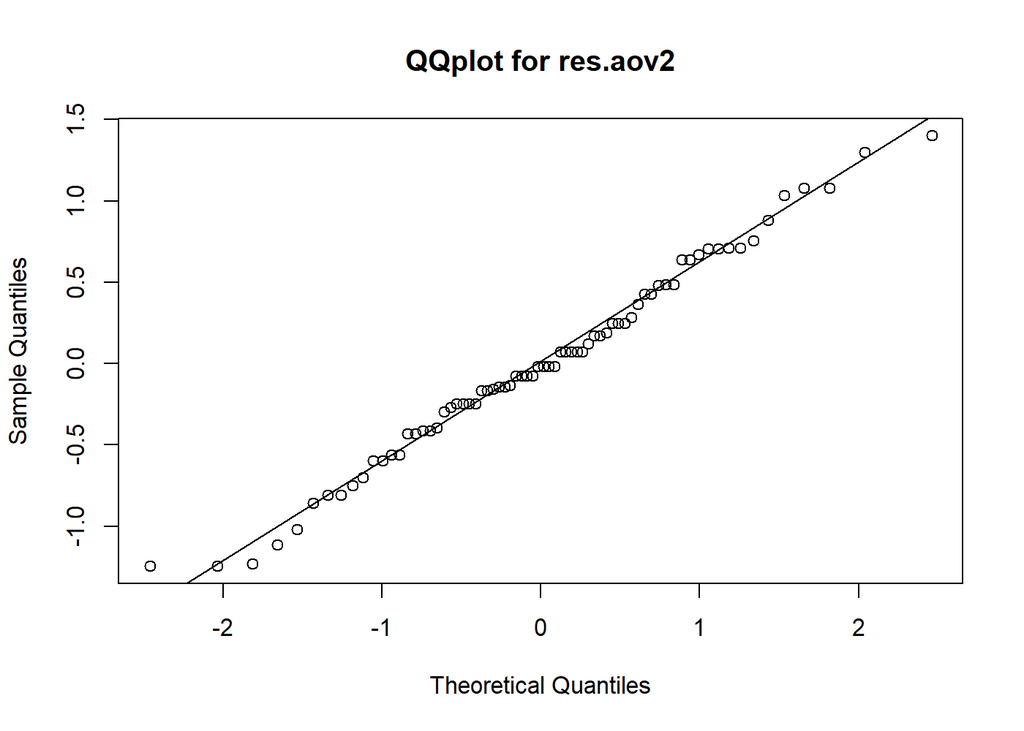

Figure 5. QQplot for comparison for res.aov1 and res.aov2

## Exercise 7:

### Which of the previous analysis is the adequate in this case? Why?

The ANOVA with the transformed count is adequate.It allowed us to prove normality. It was more accurate than the direct ANOVA into detecting significant differences between sprays. For example, the diffence between spray C and spray D was detected.

### Is there any difference in the results between the square root transformed ANOVA and the Kruskal-Wallis analyses?

There was no difference in the transformed ANOVA and the Kruskal-Wallis analyses. Both presented the same significance difference between the sprays using the alphabets.

### Is there any difference in the results between the direct ANOVA and the square root transformed ANOVA? Which ones?

There is a difference between the two ANOVAs. The square root transformed ANOVA (res.aov2) exposed the statistical difference between spray C and spray D which was not shown in the direct ANOVA (res.aov1)